# Term Project, Short RMD File

Max Snyder and Gordon Kamer

Our term project uses the 2016 Time Series Study by the American National Election Survey, which can be found at https://electionstudies.org/project/2016-time-series-study/. This survey involved 4270 respondents who answered a large array of questions before and after they voted in the 2016 election – the original dataset had 1837 columns of various types of data (we cut it to 34 to save space for the upload). This plethora of statistics allowed us to analyze various factors that affected the results of the election. We embarked on four in-depth studies:

1. Comparing voter enthusiasm toward Clinton and Trump
2. Analyzing the belief that Obama is Muslim
3. Modeling the probability of a Trump vote
4. Finding correlation between opinions on policies

Here is the barplot for the 2016 election. Notice that the sample is basically a good representation of the national electorate.

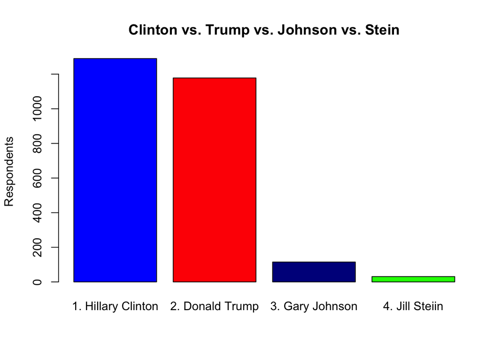

## Study #1

#### Clinton vs. Trump 2016

We first use linear regression to model the relationship between respondents’ “feeling thermometer” score (1-100) for the two major party candidates.

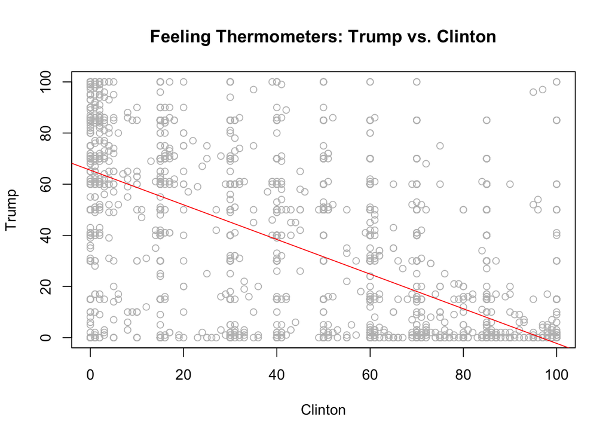

There is a clear negative relationship between the two, which is expected. We found that a slightly better model, in fact, was exponential decay. Here is the graph:

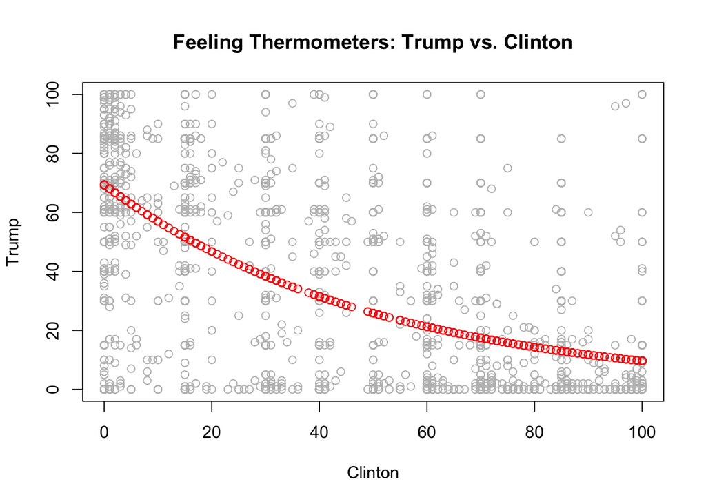

This model fits better (slightly higher correlation), likely because the high amount of “0” responses for both candidates pulls the line of best fit towards the axes.

We continue with a permutation test to discover if Clinton voters gave her a higher feeling thermometer rating than Trump voters did for Trump. The observed difference of (Clinton - Trump) between their respective voters was:

```
## [1] 2.498475
```

Here is the histogram of the permutation test’s 50000 differences of (Clinton - Trump) feeling thermometer scores. The blue curve is a normal distribution overlayed (guaranteed by CLT) and the red line indicates the observed difference of ~2.5 points.

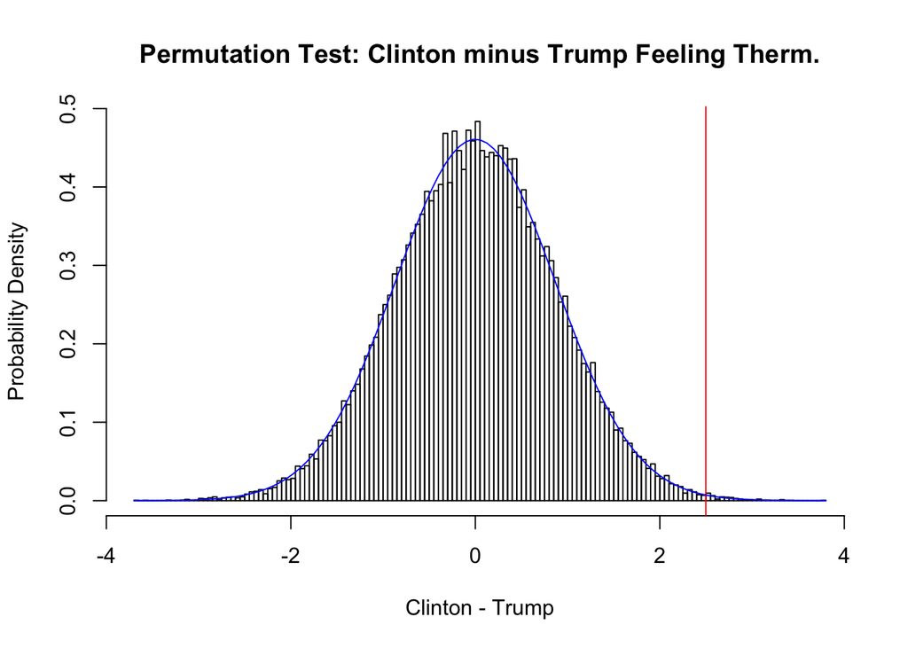

This difference of ~2.5 points out of 100 is predicted with the following p-value on a 1-sided test (predicting Clinton > Trump):

```
## [1] 0.002359953
```

We can conclude that Hillary voters liked Hillary MORE than Trump’s liked Trump on average. It suggests that Republicans might have held their nose and voted for Trump, while Hillary voters liked her more. This result is surprising in comparison to the media coverage on the topic.

## Study #2

#### Belief that Obama is Muslim

We used contingency tables to analyze the relationship between party ID, belief in vaccines, and sentiment on the economy with the belief on whether or not Obama is Muslim. Here are the tables:

```
##                  party
## muslim            1. Democratic party 2. Republican party
##   1. Muslim                       108                 259
##   2. Not a Muslim                 656                 282
```

Percentage of Democrats who answered Muslim:

```
## [1] 0.1413613
```

Percentage of Republicans who answered Muslim:

```
## [1] 0.4787431
```

There are appears to be a relationship between being a republican and believing Obama is a Muslim. Using a chi-square test, we analyze this relationship:

```
##
##  Pearson's Chi-squared test with Yates' continuity correction
##
## data:  muslim and party
## X-squared = 176.69, df = 1, p-value < 2.2e-16
```

Now let’s compare beliefs about vaccines and a respondent’s view on whether Obama is a Muslim.

```
##                  vaccines
## muslim            1. Favor 2. Oppose
##   1. Muslim            738       114
##   2. Not a Muslim     1928       162
```

Percentage of those who favor vaccines who answered Muslim:

```
## [1] 0.2768192
```

Percentage of those who oppose vaccines who answered Muslim:

```
## [1] 0.4130435
```

If you oppose vaccines, you are far more likely to believe that Obama is a Muslim. The p value showing that this relationship is significant:

```
## [1] 2.868599e-06
```

OK - now what about views on the economy? Are the “forgotten men and women” - who believe the economy has gotten worse since 2008 - more like to believe Obama is a Muslim?

Let’s take only people who answered “better” or “worse” - leaving out people who say “about the same”, for the simplicity of the table

```
##                  economy
## muslim            1. Better 2. Worse
##   1. Muslim             180      606
##   2. Not a Muslim      1300      532
```

Here is the percentage of those who believe the economy has gotten better who believe Obama is a Muslim:

```
## [1] 0.1216216
```

Here is the percentage of those who believe the economy has gotten worse who believe Obama is a Muslim:

```
## [1] 0.5325132
```

The difference here is even MORE striking than the party comparison! Here is the p-value:

```
## [1] 5.094042e-114
```

As you can see, we have very strong statistical proof (p < .001) that each of variables are correlated with beliefs about whether Obama is a Muslim. The most related variable in this study is not party ID but in fact belief about the strength of the economy since 2008, which is surprising.

## Study #3

#### Predicting Probability of a Trump Vote

We attempted to see if we can predict if someone is going to vote for Trump before that person even steps foot in the ballot box. This is incredibly important for political campaigns, and many campaigns have models that attempt to do this.

First, we did a simple logistic regression curve using only the self-reported **liberal/conservative placement on a 7 point scale**. While in this case, it may make more sense just to look at the probabilites for each specific score, this approach works much better when we put many more variables into the model.

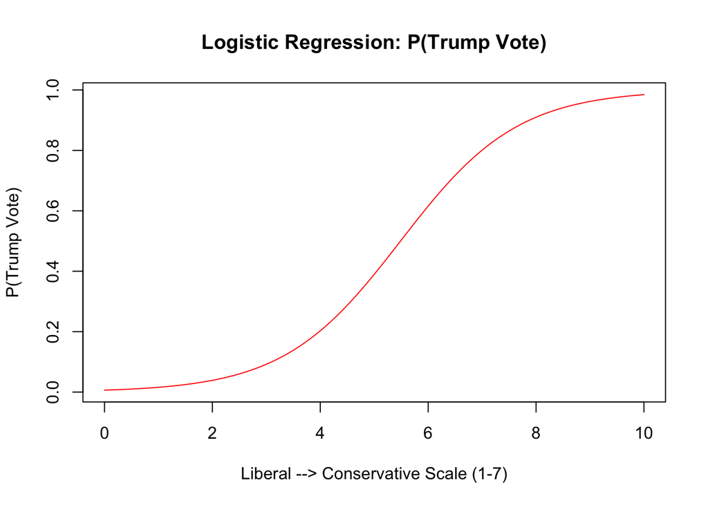

Overlaying the actual data (using a “jitter” offset to make it easier to see density of data), we see the following:

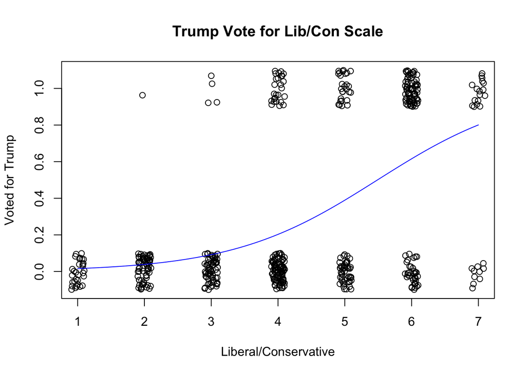

This curve does a somewhat good job, but we moved on to a more robust model. We included the following **political variables** in our analysis:

1. Liberal/Conservative 7pt scale - V161126
2. Party ID - V161158x
3. How to select justices for the Supreme Court - V161176
4. Build a wall - V161196/V161196a
5. Trust in washington - V161215
6. Is global warming happening - V161221
7. Gay marriage - V161231
8. Is bible the word of God or men - V161243
9. Days in week that you watch news - V161008
10. Should illegal aliens be sent back - V161195
11. Is economy better off since 2008 - V161235

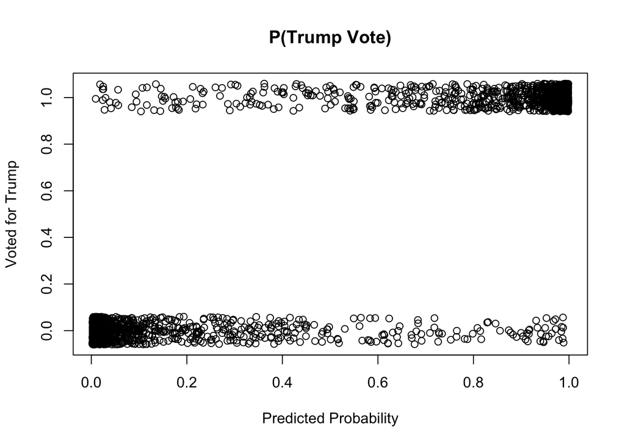

As you can see, the density of points in the top right and bottom left corners of the plot indicate graphically that the model is doing a decent job.

What percentage of the time does the model get it correct (threshold = 50%)?

```
## [1] 0.9140734
```

This model is correct more than 90% of the time! However, we decided to incorporate a number of **NON-political variables** as well:

Whether the respondent watches/reads:

12. Hannity - V161370
13. Rachel Maddow - V161393
14. NYTimes - V161451
15. Modern Family - V161373
16. Sunday Night Football - V161376
17. House of Cards - V161385
18. Game of Thrones - V161389

~ ~ ~ ~

19. How often respondent attends church - V161245
20. Is the respondent white, black, or latino (doesn’t count other but doens’t leave them out)

Percentage that this **new** model is correct:

```
## [1] 0.9167734
```

This was a very modest improvement, but an improvement nonetheless. Some interesting findings from this study:

1. It seems from the summary analysis that the only race that mattered was being white or not (being Black or Latino was not salient).
2. It also looks like the only media that added to the model significantly were Modern Family and the NYTimes, both with negative coefficients. This is interesting: if you watch Modern Family, we can predict that you’re more likely to not vote for Trump.

## Study #4

#### Correlation between Policies

Given that you like government spending on healthcare, what do you think about defense spending? The survey includes at least four variables which respondents give on a 7 point scale:

1. Defense Spending
2. Healthcare
3. The Environment
4. Government Services Spending

Before we start, here are histograms that reflect the ideological distribution on these issues among respondents:

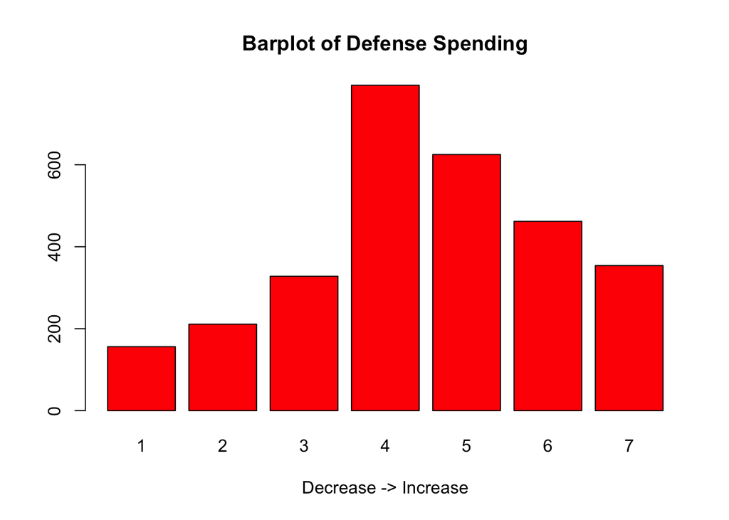

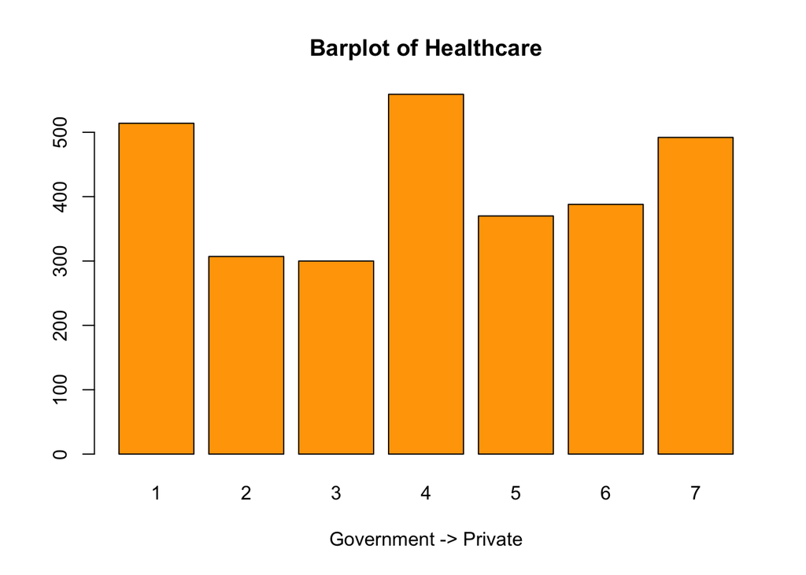

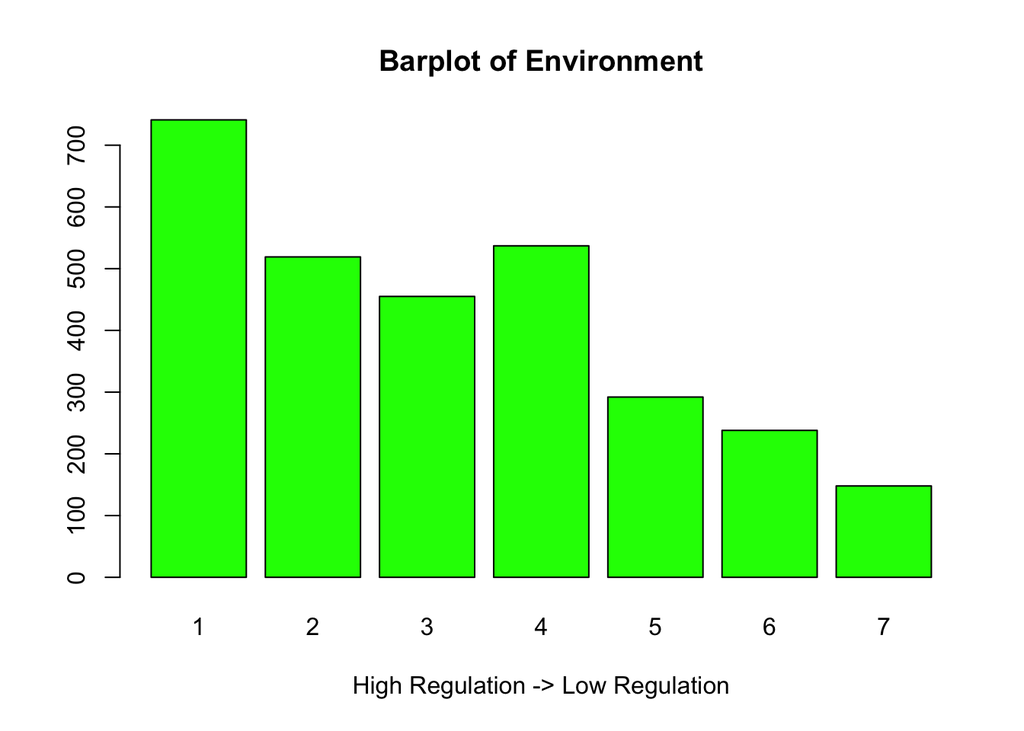

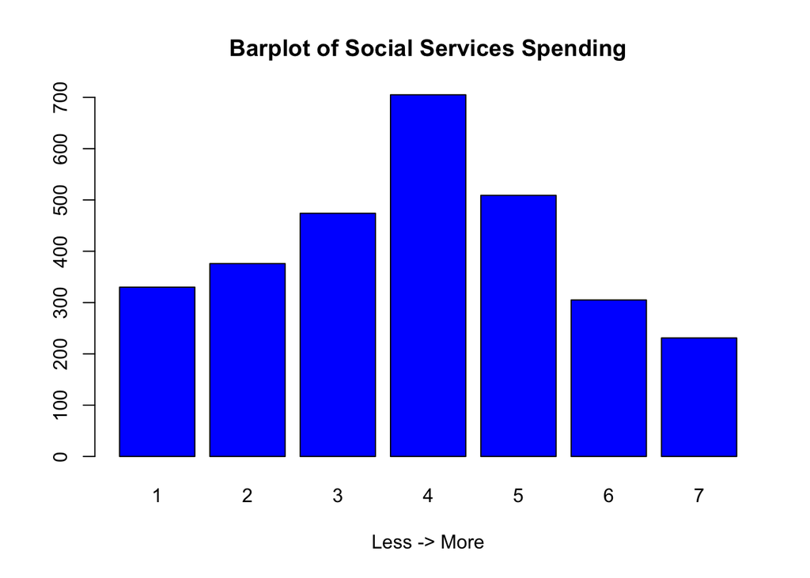

Here is a correlation matrix between the four variables:

```
##                Defense Healthcare Environment   Spending
## Defense      1.0000000  0.4001237   0.3698605 -0.2494688
## Healthcare   0.4001237  1.0000000   0.5233807 -0.5452691
## Environment  0.3698605  0.5233807   1.0000000 -0.4920432
## Spending    -0.2494688 -0.5452691  -0.4920432  1.0000000
```

Here are examples of how beliefs on healthcare interact with two other variables:

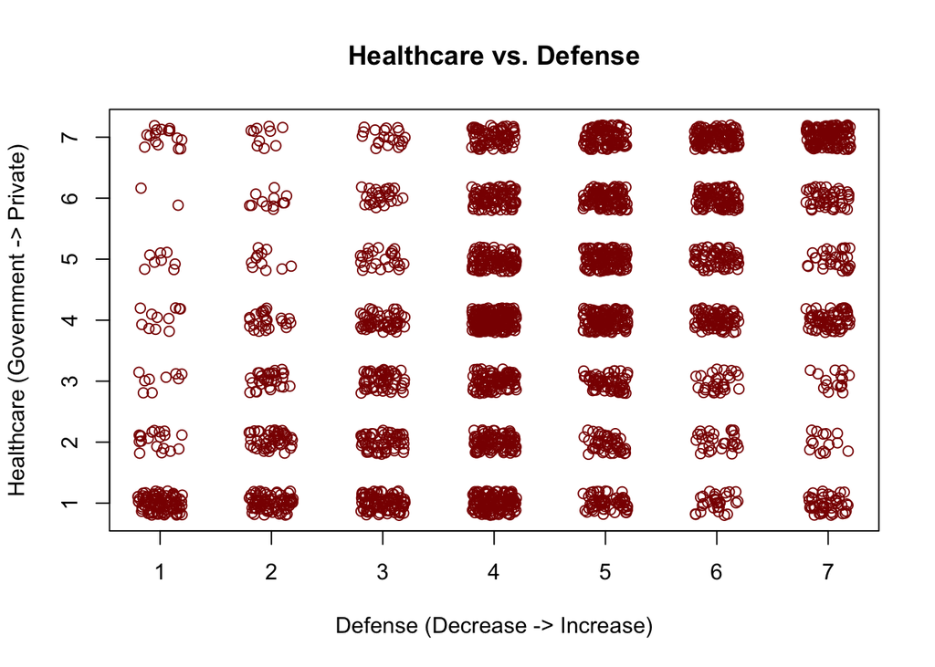

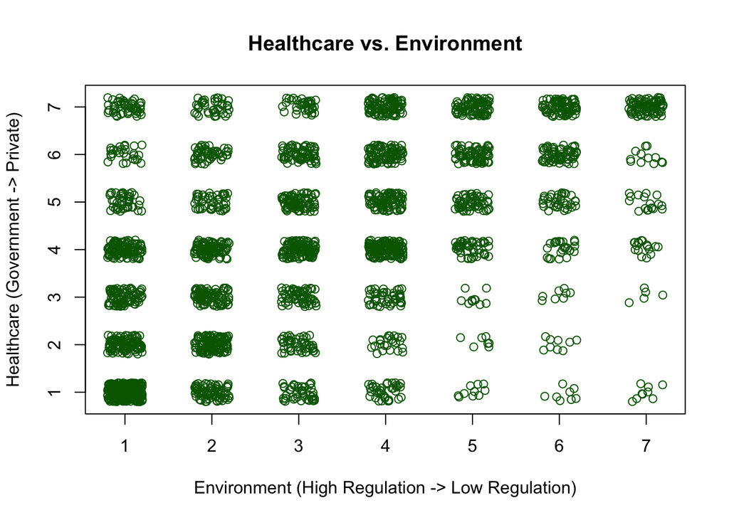

No mistake: they’re clearly correlated, and the correlation appears linear. This type of analysis illuminates how the parties align on certain issues. Today, our parties mostly reflect the conservative/liberal divide, which is reflected in the correlations between the variables.

## Conclusion

These four sub-studies have revealed telling information about the 2016 election – all thanks to the statistical tests from Math 23c. Please see the longer .R script for further explanation of these analyses.